# Statistical_Method_Assignment

Dimitra Muni (LiU ID: dimmu472)

10/29/2019

# 4.84 Gamma Distribution

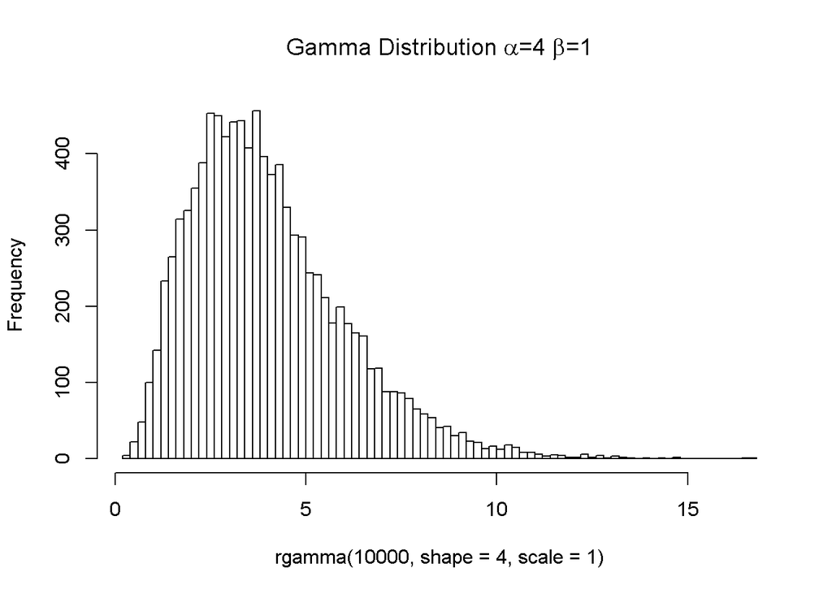

```r
hist(rgamma(10000,shape = 4,scale = 1),breaks = 100,main = expression(paste("Gamma Distribution ",alpha,"=",4," ",beta,"=",1)))
```

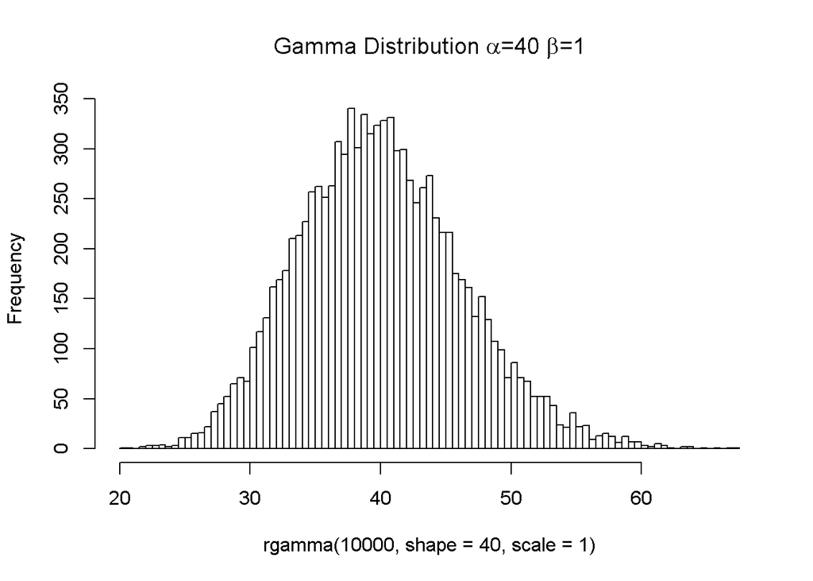

```r
hist(rgamma(10000,shape = 40,scale = 1),breaks = 100,main = expression(paste("Gamma Distribution ",alpha,"=",40," ",beta,"=",1)))
```

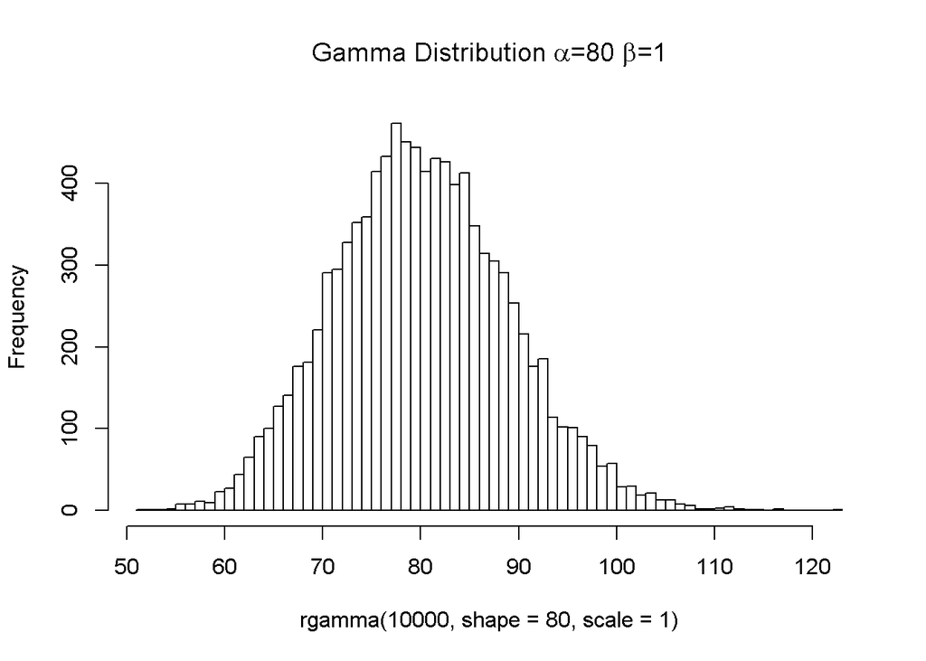

```r
hist(rgamma(10000,shape = 80,scale = 1),breaks = 100,main = expression(paste("Gamma Distribution ",alpha,"=",80," ",beta,"=",1)))
```

**a** What do you observe about the shapes of these three density functions? Which are less skewed and more symmetric?

**b** What differences do you observe about the location of the centers of these density functions?

Location of centers correspond to shape(alpha) parameter in the density function, its centered around alpha and its porportional to it.

**c** Give an explanation for what you observed in part (b)

As the alpha increases location centers increase.

# 4.117 Beta Distribution

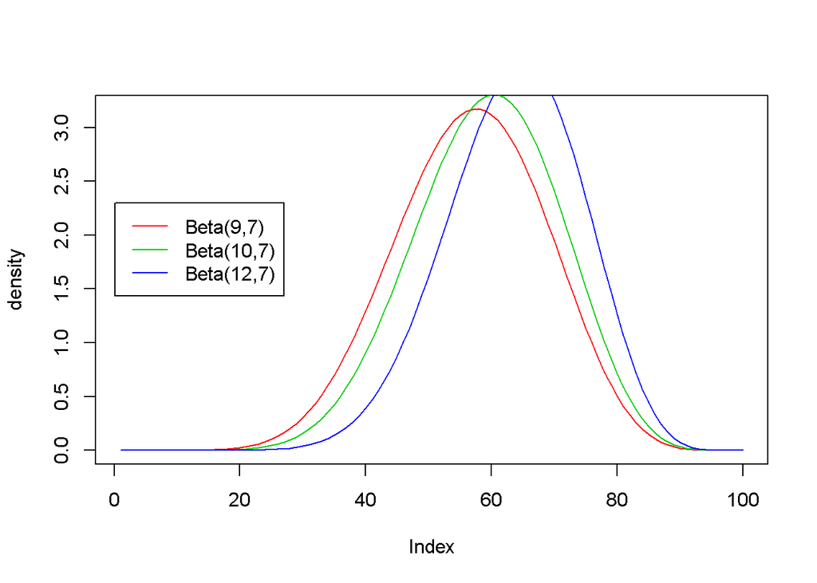

```r
p=seq(0,1,length.out = 100)
plot(dbeta(p,shape1 =9, shape2 =7), ylab="density",type ="l", col=2)
lines(dbeta(p,shape1 =10, shape2 =7),type ="l", col=3)
lines(dbeta(p,shape1 =12, shape2 =7),type ="l", col=4)
legend(0.1,2.3, c("Beta(9,7)","Beta(10,7)", "Beta(12,7)"),lty=c(1,1,1),col=c(2,3,4))
```

**c** Graph some more beta densities with α > 1,β> 1, and α>β. What do you conjecture about the shape of beta densities with α>β and both α > 1 and β > 1?

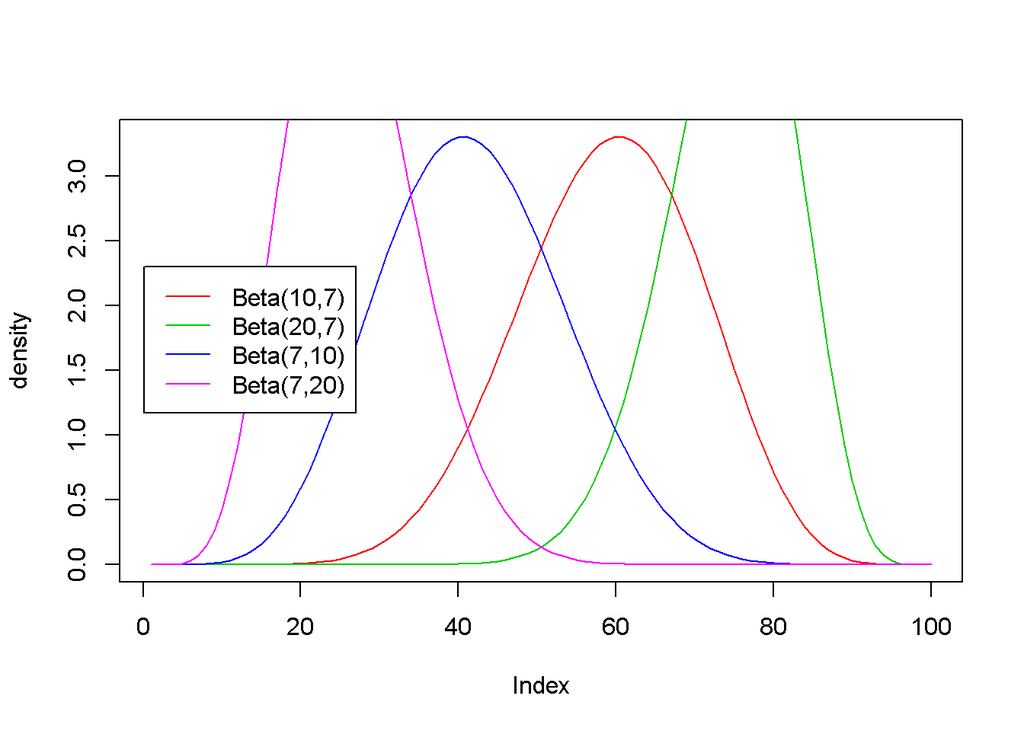

```r
p=seq(0,1,length.out = 100)
plot(dbeta(p,shape1 =10, shape2 =7), ylab="density",type ="l", col=2)
lines(dbeta(p,shape1 =20, shape2 =7),type ="l", col=3)
lines(dbeta(p,shape1 =7, shape2 =10),type ="l", col=4)
lines(dbeta(p,shape1 =7, shape2 =20),type ="l", col=6)
legend(0.1,2.3, c("Beta(10,7)","Beta(20,7)", "Beta(7,10)","Beta(7,20)"),lty=c(1,1,1,1),col=c(2,3,4,6))
```

For α > 1,β> 1 it can be observed that, for constant β value increasing α value results in distribution skewed towards right While for constant α value, increasing β has distribution skewed towards left.

Now, for α>β

when α > 1,β> 1, It can be observed that when α is increasing its skewed towards right, and the dispersion is less.It becomes more focused.

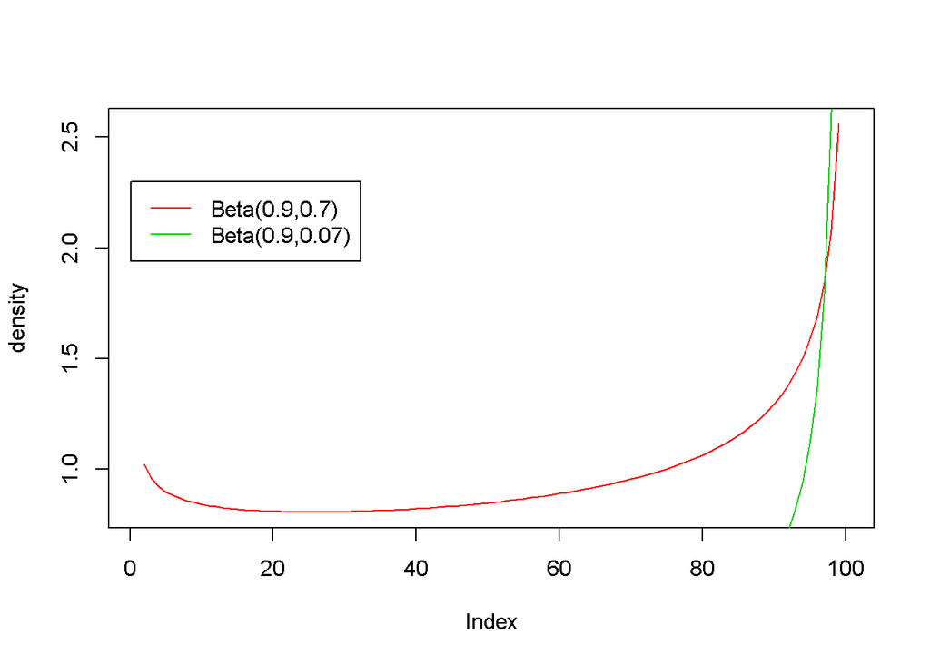

```r
p=seq(0,1,length.out = 100)
plot(dbeta(p,shape1 =0.9, shape2 =0.7), ylab="density",type ="l", col=2)
lines(dbeta(p,shape1 =0.9, shape2 =0.07),type ="l", col=3)
legend(0.1,2.3, c("Beta(0.9,0.7)","Beta(0.9,0.07)"),lty=c(1,1),col=c(2,3))
```

when, 0< β< α < 1, The distribution has exponential behavior.When the difference between them is large, it grows even faster.

# 4.118 Beta Density Functions

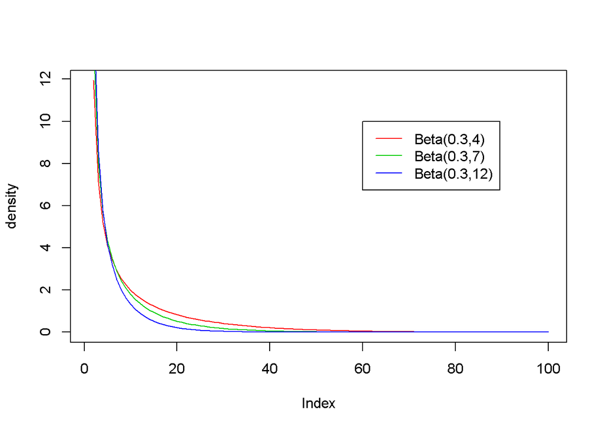

```r
p=seq(0,1,length.out = 100)
plot(dbeta(p,shape1 =0.3, shape2 =4), ylab="density",type ="l", col=2)
lines(dbeta(p,shape1 =0.3, shape2 =7),type ="l", col=3)
lines(dbeta(p,shape1 =0.3, shape2 =12),type ="l", col=4)
legend(60,10, c("Beta(0.3,4)","Beta(0.3,7)", "Beta(0.3,12)"),lty=c(1,1,1),col=c(2,3,4))
```

**a** Are these densities symmetric? Skewed left? Skewed right?

Here densities are skewed right.

**b** What do you observe as the value of β gets closer to 12?

As value of β gets closer to 12 the curve is get more sharper with less spread.And for higher value of β, it acts as signum function

**c** Which of these beta distributions gives the highest probability of observing a value larger than 0.2?

```r
pbeta(0.2, shape1=0.3, shape2=4,lower.tail = FALSE)
```

```
## [1] 0.1106419
```

```r
pbeta(0.2, shape1=0.3, shape2=7,lower.tail = FALSE)
```

```
## [1] 0.04286829
```

```r
pbeta(0.2, shape1=0.3, shape2=12,lower.tail = FALSE)
```

```
## [1] 0.01046609
```

For alpha=0.3 and beta=4 distribution has higest probability of observing value larger than 0.2

**d** Graph some more beta densities with α < 1 and β > 1.

[figure not shown]

```r
p=seq(0,1,length.out = 100)
plot(dbeta(p,shape1 =0.3, shape2 =4), ylab="density",type ="l", col=2)
lines(dbeta(p,shape1 =0.03, shape2 =4),type ="l", col=3)
lines(dbeta(p,shape1 =0.003, shape2 =4),type ="l", col=4)
legend(60,10, c("Beta(0.3,4)","Beta(0.3,7)", "Beta(0.3,12)"),lty=c(1,1,1),col=c(2,3,4))
```

What do you conjecture about the shape of beta densities with α < 1 and β > 1?

All of these have similar shape but by reducing α by factor of 10, made the curve sharper.